# Assignment 2

Bhagyarathi Raman

2/4/2022

Examine the normal distribution using: µ= 1, σ=2.

1. Plot the normal density curve over the range (-5, 7).

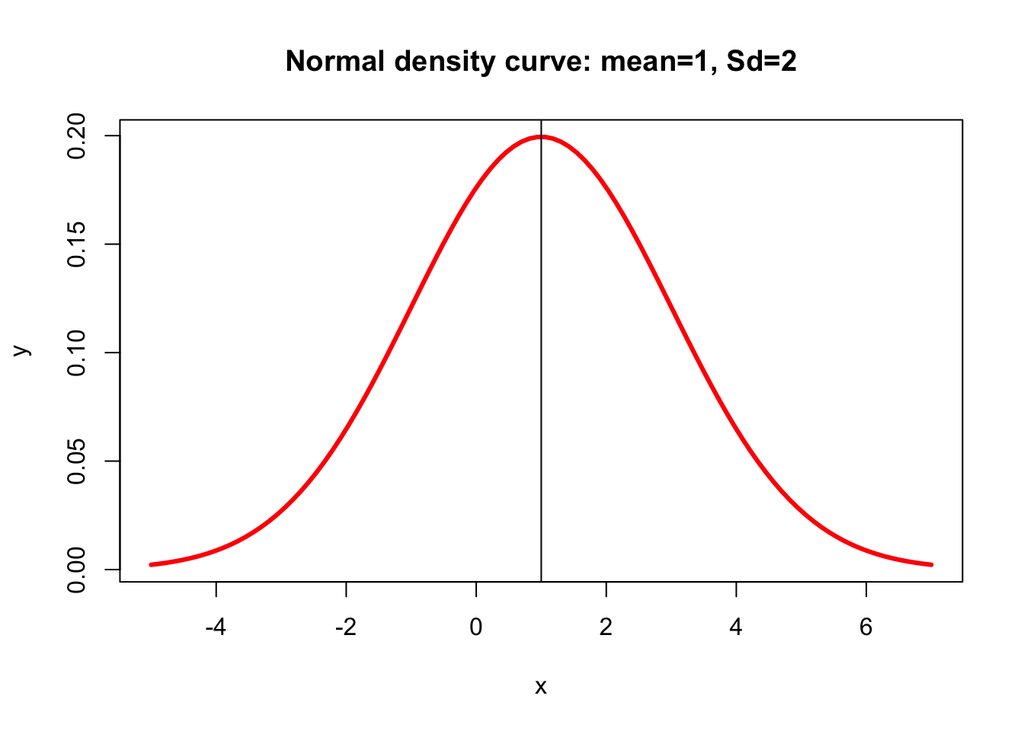

```r
mean=1
sd=2
x<-seq(from= -5, to = 7,length.out=100)
y<-dnorm(x,mean,sd)
plot(x,y,type="l", main="Normal density curve: mean=1, Sd=2", col="red",lwd=3)
abline(v=1)
```

2. What is the quantile for P = 0.975?

```r
p=0.975
qnorm(p, mean, sd)
```

```
## [1] 4.919928
```

3. What is the probability that one random draw will be observed in the interval (-3, 5)?

```r
pnorm(5,1,2)-pnorm(-3,1,2)
```

```
## [1] 0.9544997
```

4. What is the probability that one random draw will be greater than 7?

```r
1-pnorm(7,mean,sd)
```

```
## [1] 0.001349898
```

```r
x<-(0:12)
n=12
p=0.3
dbinom(x,n,p)
```

```
##  [1] 1.384129e-02 7.118376e-02 1.677903e-01 2.397004e-01 2.311397e-01
##  [6] 1.584958e-01 7.924790e-02 2.911147e-02 7.797716e-03 1.485279e-03
## [11] 1.909645e-04 1.488035e-05 5.314410e-07
```

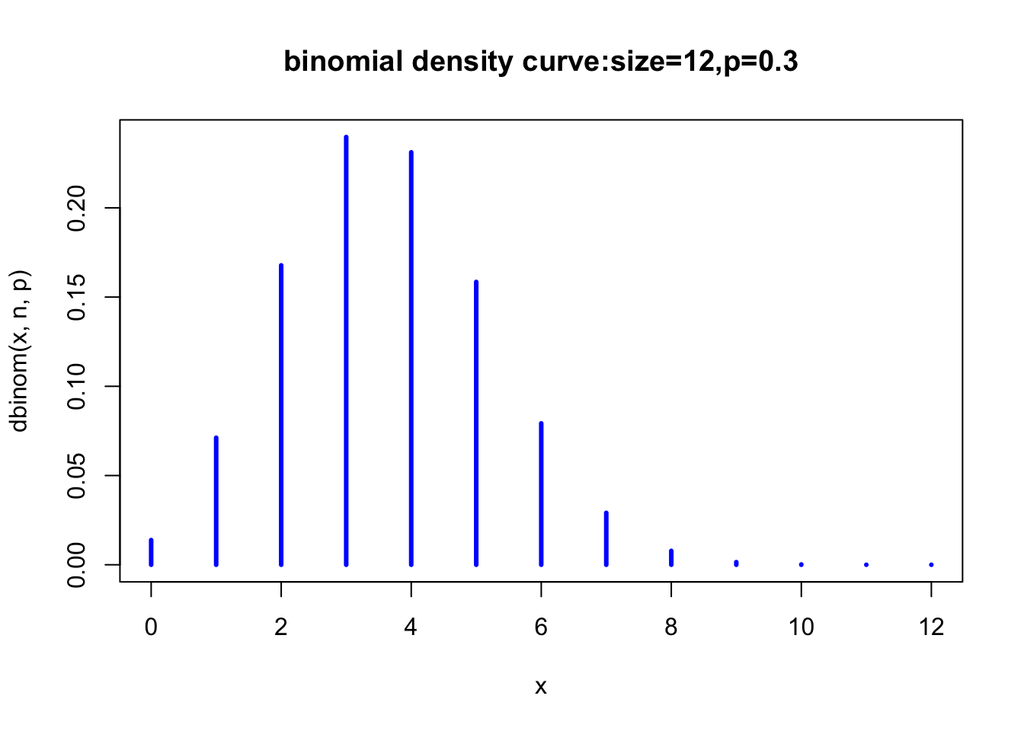

```r
plot(x,dbinom(x,n,p),type="h", main="binomial density curve:size=12,p=0.3",col="blue",lwd=3)
```

6. What is the quantile for P = 0.99?

```r
P=0.99
qbinom(P,n,p)
```

```
## [1] 7
```

7. What is the probability that one random draw will be observed in the interval (0,4)?

```r
pbinom(4,n,p)-pbinom(0,n,p)
```

```
## [1] 0.7098142
```

8. What is the probability that one random draw will be greater than 3?

```r
n=12
p=0.3
pbinom(3,n,p,lower.tail = FALSE)
```

```
## [1] 0.5074842
```

9. A purchasing manager gets the memo about replacing some aging trucks in the moving company’s fleet for the next fiscal year. After discussing the task with the fleet manager and sales manager, she finds that replacing the three oldest trucks with newer three-year-old trucks will be sufficient for next year’s operations. She finally gets a budget of $450000 dollars to purchase three trucks. Upon consulting used-truck sales data, she finds that for three-year-old trucks, the average sales price is $156818 with a standard deviation of $8000. She decides to get bids from 12 dealers for purchasing one three-year-old truck, assuming she will take the three lowest bids. Assume the delivery costs are zero, and the sold-truck-price is normally distributed with a mean of 156818 and a standard deviation of 8000, what is the probability she will be able to purchase the three trucks within the budget?

```r
x=450000
mean=156818
sd=8000
pnorm(x,mean,sd)
```

```
## [1] 1
```